# peer graded regression models

sayonee

11/6/2020

*Created with knitr*

#### SUMMARY FOR THE FOLLOWING PROJECT

This report is using the the relationship between transmission type and miles per gallon (MPG).we need t find which gives the higher mpg according to the dataset given #### we are Loading the given Dataset we thus load the dataset and convert to proper factors.

```r
library(ggplot2)
data(mtcars)
head(mtcars, n=3)
```

```
##                mpg cyl disp  hp drat    wt  qsec vs am gear carb
## Mazda RX4     21.0   6  160 110 3.90 2.620 16.46  0  1    4    4
## Mazda RX4 Wag 21.0   6  160 110 3.90 2.875 17.02  0  1    4    4
## Datsun 710    22.8   4  108  93 3.85 2.320 18.61  1  1    4    1
```

```r
dim(mtcars)
```

```
## [1] 32 11
```

```r
mtcars$cyl<- as.factor(mtcars$cyl)
mtcars$vs<- as.factor(mtcars$vs)
mtcars$am<- factor(mtcars$am)
mtcars$ger <-factor(mtcars$gear)
mtcars$cart <-factor(mtcars$carb)
attach(mtcars)
```

#### we continue with the Exploratory Analysis of the data set

showing an Exploratory Box graph ##### Statistical Inference testingtransmission type and Miles per galons

```r
trr <- t.test(mpg ~ am)
trr$p.value
```

```
## [1] 0.001373638
```

The T-Test is discarding the hypothesis such that the possible difference between all the transmission types is 0.

```r
trr$estimate
```

```
## mean in group 0 mean in group 1
##        17.14737        24.39231
```

The difference estimate between the 2 transmissions is 7.24494 MPG in favor of manual.

##### Regression Analysis

Fit the full model of the data

```r
fmt <- lm(mpg ~ ., data = mtcars)
summary(fmt)  # results hidden
summary(fmt)$coeffrdrr  # results hidden
```

Since none of the coefficients have a p-value less than 0.05 we cannot conclude which variables are more statistically significant.

Backward selection to determine which variables are most statistically significant

```r
sit <- step(fmt)
summary(sit) # results hidden
summary(sit)$coeffrdrr # results hidden
```

The new model has 4 variables (cyls, hp, wt, trans). thus we know that the Rsquared value of 0.8659 states that the given model suggests about 87% of the varance. .

####Residue__Diagnostic Plot

The plots conclude:

1. The randomness of the Residuals vs. Fitted plotsuggests assumption of independence
2. The points of the Normal Q-Q plot is following closeto the line concluding that the distribution of residua is normal
3. The Scale-Loca plot random distribution confirms the constant variance assumption
4. Since all points are within the lines, the Residus vs. Leverge concludes that there are no outliers

```r
sum((abs(dfbetas(sit)))>1)
```

```
## [1] 0
```

#### Conclusion

There is a difference in MPG based on transmission type. A manual transmission will have a slight MPG boost. However, it seems that weight, horsepower, & number of cylinders are more statistically significant when determining MPG.

### Appendix Figures

#### I

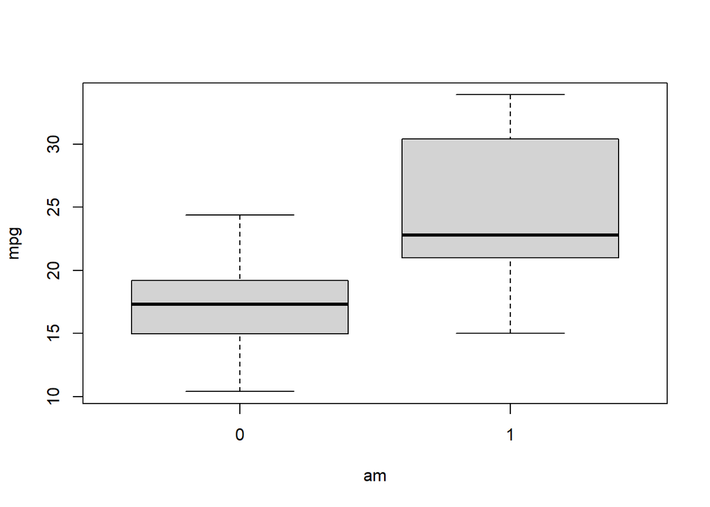

#### II

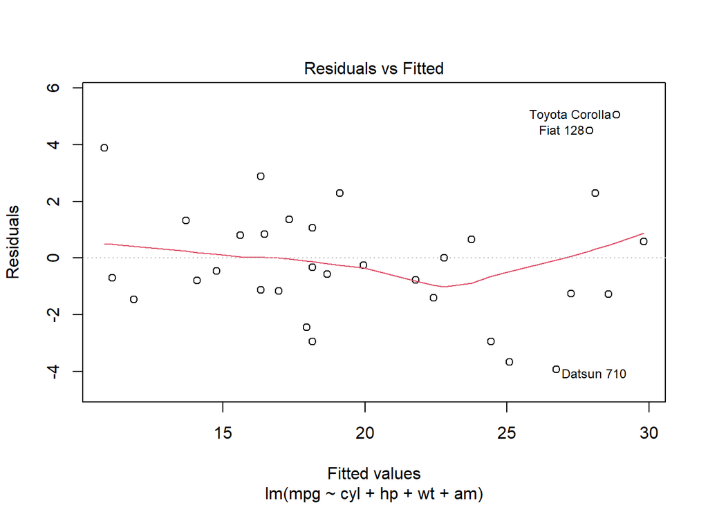

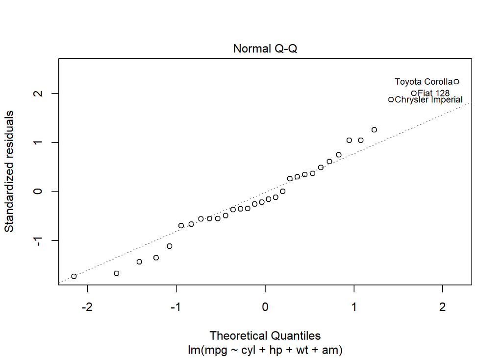

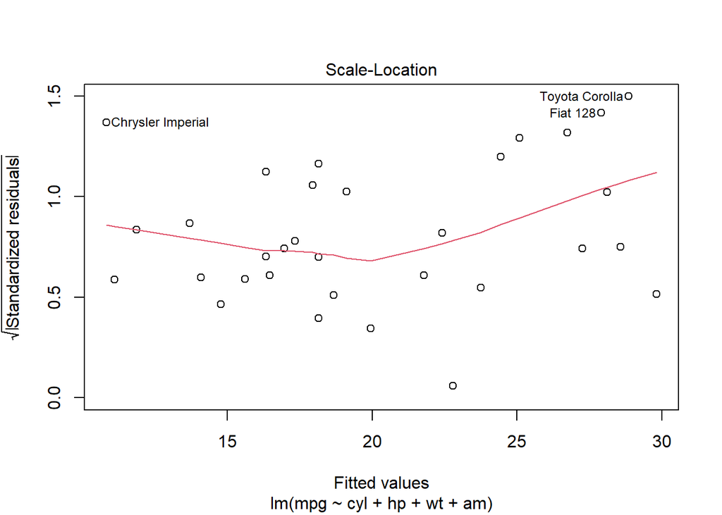

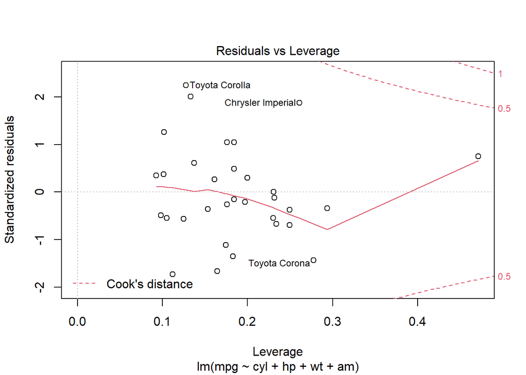